# Exploring and Communicating Data Findings of FordGoBike Data, San Francisco, To Identify Growth Opportunies Among User Segments

## by (Doaa Salahedin Ahmed)

02/2021

## Univariate Exploration

> - In this section, we will start investigate the different distributions of individual variables to explore and prepare for the subsequent investigation of the relationships between variables.

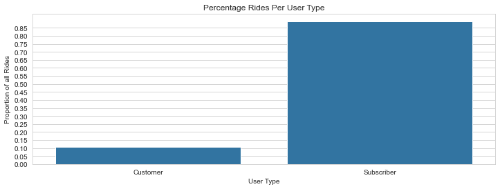

> - The majority of rides belongs to users of the subscribers category.

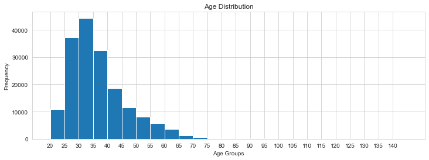

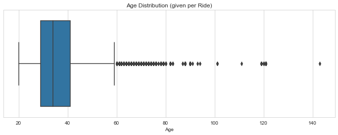

> - The boxplot shows, like the histogram before, that the majority of ages around 30. Unlike the histogram, the boxplot reveals outliers, which need to be investigated. The outliers between 60 and 100 years seem reasonable, however, to use this service one needs to know how to operate with apps and needs to understand that the service is based on internet connectivity in addition to the physical ability to ride bikes, this induced these outliers.

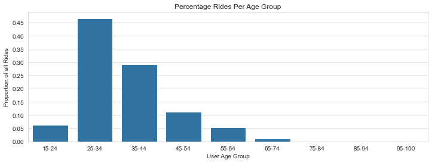

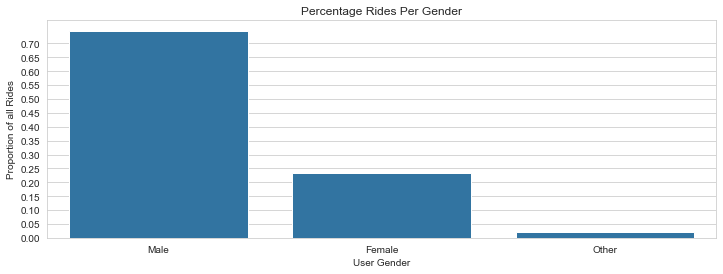

> - The majority of rides has been made by males where a very limited number did not specify their gender to male nor female.
> - To demonstrated the distribution of trip duration, we need to conver the duration_sec variable to a more respresnting scale, in our case a a good measuring scale for a trip would be in minutes.

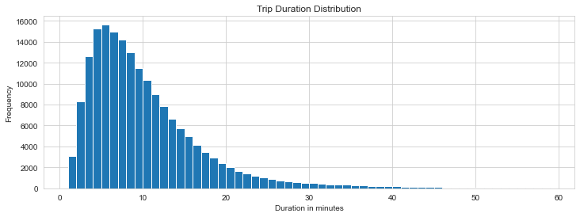

> - From the above histogram we can find that the majority of the trips durations are below 45 minutes, however, this insight didn't differentiate the trip duration per user type. Therefore, we will investigate this attribute later.

### Of the features you investigated, were there any unusual distributions? Did you perform any operations on the data to tidy, adjust, or change the form of the data? If so, why did you do this?

> - The most interesting features for us are relevant to usage pattrens in terms of the number of rides, durations and duration per ride. We have to explore our targeted audience (segment of user by user type, gender and age) to determine their usage patterns and preferences. This exploration shall provide guidance for potential business opportunities.

## Bivariate Exploration

> In this section, we are going to investigate relationships between pairs of variables within our FordGoBike dataset to analyze the amount of rides against the users segmentations by age and gender. We will also elaborate, trip duration, and amount of rides, the duration, and the duration per ride and user group later on.

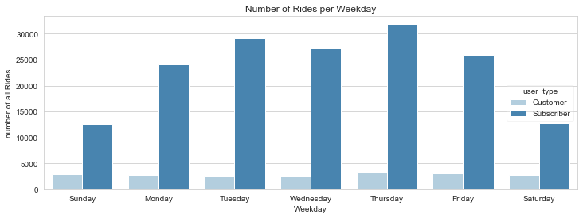

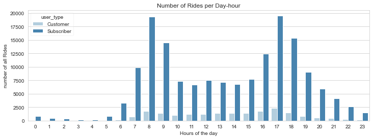

> - From the above patterns we can see that the mojrity of the trips took place during the early morning hours and during afternoons, this suggests that customers mainly use this service to arrive and to return back to their scool/work.

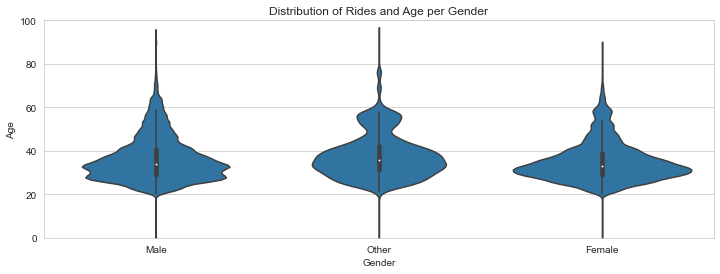

> The above violin plots show the following:
> - Users of higher ages are observed to be mainly male users, this is demonstrated by the more stretched distribution towards higher ages.
> - Denser distribution of female users arount the age of thirty, is shown by the interquartile distance demostrated by the shorter thick violin middle line and the width of the violin.
> - We can confirm these insights by a clustered barplot showing the relationship between the age group and gender against the percentage of rides:

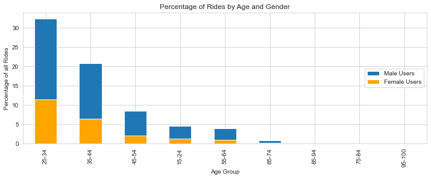

> - This clustered barplot shows that most rides were done by male users within the 25-34 age group, in addition to higher usage within the male users for all age groups.

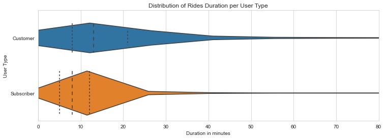

> - The two violin plots show the relative distribution of the trip duration (in minutes) for each membership type where is a clear difference in the distribution of trip duration between the 2 user types.
> - The subscribers tend to take shorter trips concentrated around 10 minutes. Whereas the customers tend to be more spreading with an average of about 15 minutes.
> - We can observe outliers within the duration variable of the subscribers. We can also see that the customers group has relatively longer trip duration than the subscribers group.

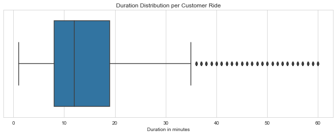

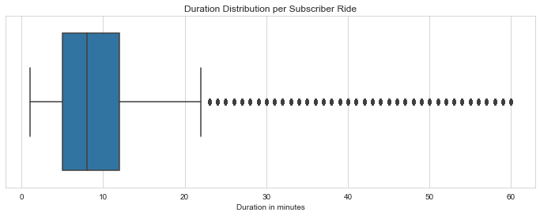

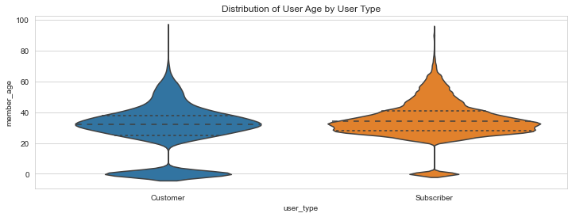

> - We can see that younger users are generally customers between 25 and 35 years old. Whereas subscribers are typically older, mainly between 30 and 40 years old and with more users between 40 and 65 years old.

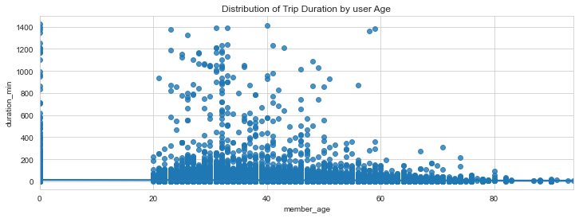

## Multivariate Exploration

> Through the previous section we have segmented our users by age and gender, now we will explore the variations of the number of rides and trips durations between the users of each segment.

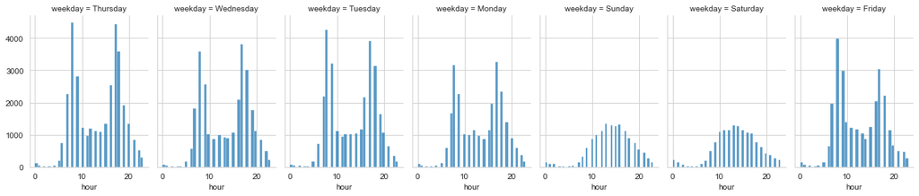

> - The week histplots confirm our previous finding of the the most frequent hours for trips, and also indicates that this explanation applies to all the week except for Sundays and Saturdays, where the rush hours look normalized.

[output not shown]

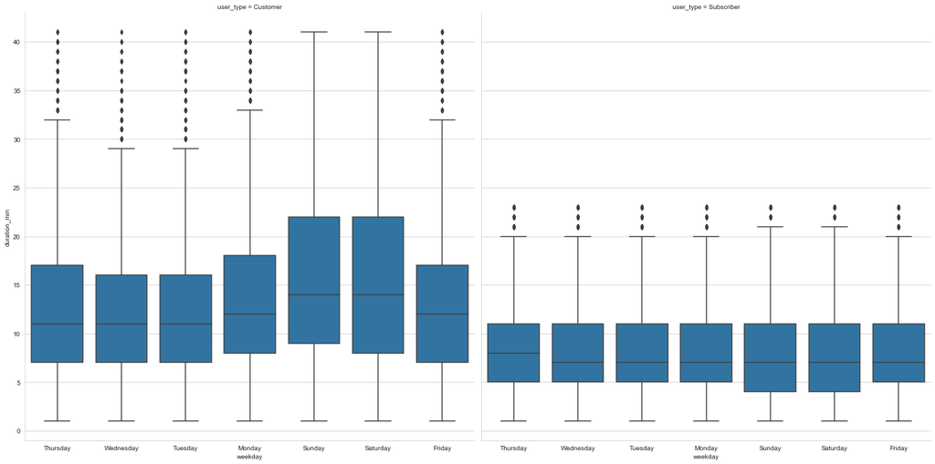

[output not shown]

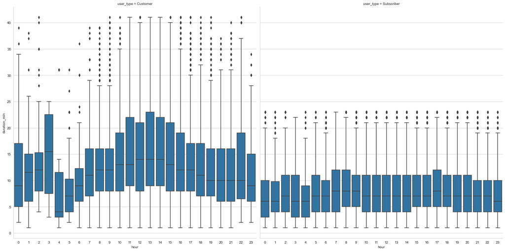

> - The Faceted boxplots highlighted the interaction between the two categorical variables, where, in level of customer (user type), the weekday and hour seem to have larg effect on the trip duration, compared to the trend within the subscribers level.
> - This finding also emphasizes the irregular pattern of customers compared to the subscribers who are expected to have more frequent rides and hence to have a greater degree of trip time management.

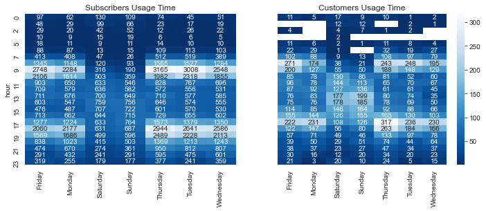

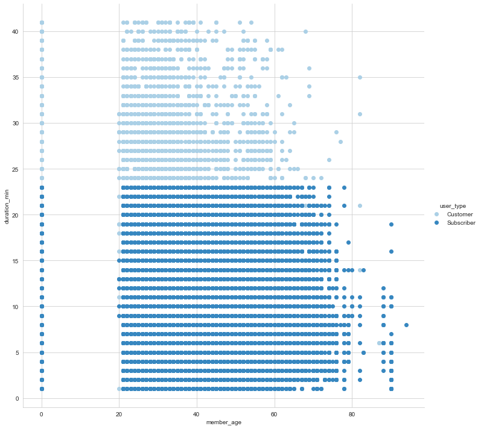

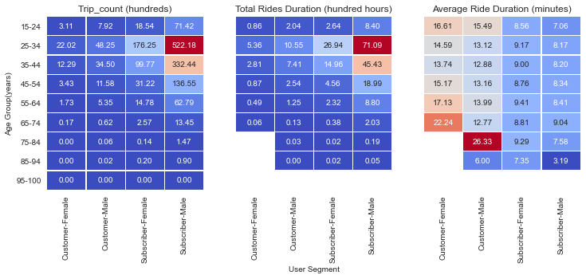

> From the first 2 heatmaps we can observe that the usage patterns (number of rides and duration) vary proportionally in a positive direction within the same user segment, for instance, users segments with higher numbers of rides are also recording higher dusrations, and this is quite logic and supported by the matched colorization hues for each segment in the 2 heatmaps.

> On the other side, the dark cooler colorizations on the first 2 heatmaps can be an indicator for untapped opportunities or otherwise non-existing need. Knowing that the female population of San Francisco are quit high, we shall advise on expanding the marketing activities and allocating more budget to penetrate this segment.